# Aula_4_apis_pt1

Author

Baruque rodrigues

#### Objetivos:

- Entender o que são APIs e como utilizá-las para coleta de dados.
- Aprender a fazer requisições GET e POST utilizando R.

#### Conteúdo:

### 1. Introdução às APIs

#### Definição e Vantagens

**API (Application Programming Interface)**: Conjunto de definições e protocolos que permitem a comunicação entre softwares. É uma ponte que permite que diferentes aplicações possam interagir e trocar dados de maneira estruturada e segura.

**Vantagens das APIs**:

- Automatização de tarefas repetitivas
- Integração de diferentes sistemas
- Acesso a dados em tempo real
- Possibilidade de uso de serviços externos (ex.: mapas, serviços de pagamento, redes sociais)

#### Tipos de APIs (REST, SOAP)

**REST (Representational State Transfer)**: Arquitetura de software que usa o protocolo HTTP para troca de dados. Vantagens: simplicidade, uso de verbos HTTP, fácil de escalar.

**SOAP (Simple Object Access Protocol)**: Protocolo baseado em XML que permite a troca de informações estruturadas. Vantagens: segurança e robustez.

### 2. Ferramentas para Trabalhar com APIs em R

#### Pacotes: httr, jsonlite e tidyverse

```r
library(tidyverse)
```

**httr**: Pacote que facilita a comunicação com APIs, permitindo enviar requisições HTTP e lidar com respostas.

```r
install.packages("httr")
library(httr)
```

**jsonlite**: Pacote para manipulação de dados JSON, comum em respostas de APIs.

```r
install.packages("jsonlite")
library(jsonlite)`
```

### 3. Acessando uma API Pública

[figure not shown]

Por que acessar os dados da API da câmara?

- **Transparência**:
  - Promove a transparência das atividades legislativas, permitindo que os cidadãos acompanhem de perto as ações dos seus representantes.
- **Accountability (Responsabilização)**:
  - Facilita a responsabilização dos deputados, já que os cidadãos podem verificar como votaram em determinados projetos e como estão gastando os recursos públicos.
- **Engajamento Cívico**:
  - Aumenta o engajamento cívico, permitindo que os cidadãos se envolvam mais ativamente no processo legislativo e nas políticas públicas.

### Por que é Interesse público

1. **Acompanhamento da Tramitação e Votações de Projetos**:
   - Os cidadãos podem acompanhar o progresso dos projetos de lei, emendas, e outras proposições, entendendo melhor o processo legislativo.
2. **Verificação da Atuação e Gastos dos Deputados**:
   - Permite que os eleitores verifiquem como os deputados estão atuando e gastando recursos, promovendo uma gestão pública mais responsável e eficiente.
3. **Transparência em Eventos e Comissões**:
   - Os dados sobre eventos realizados pelas comissões são importantes para monitorar discussões e decisões que podem impactar diretamente a vida dos cidadãos.
4. **Facilitação de Pesquisas Acadêmicas e Jornalísticas**:
   - Disponibiliza informações essenciais para pesquisas acadêmicas, reportagens investigativas e análises políticas, contribuindo para uma sociedade mais bem informada.
5. **Desenvolvimento de Ferramentas e Aplicações**:
   - Desenvolvedores e empresas podem criar ferramentas que tornem os dados mais acessíveis e utilizáveis para o público em geral, como aplicativos que alertam sobre votações importantes ou que analisam o desempenho de deputados.
6. **Participação Informada**:
   - Com acesso a informações detalhadas, os cidadãos podem tomar decisões mais informadas nas eleições e em outras formas de participação política.

### Do que fala deputado? Analisando o discurso dos Deputados Federais

Para analisar o discurso dos deputados podemos acessar a [API de Dados abertos](https://dadosabertos.camara.leg.br/swagger/api.html)

[figure not shown]

Na aba de deputados encontramos o endpoint da api que contém os discursos feitos pelos deputados

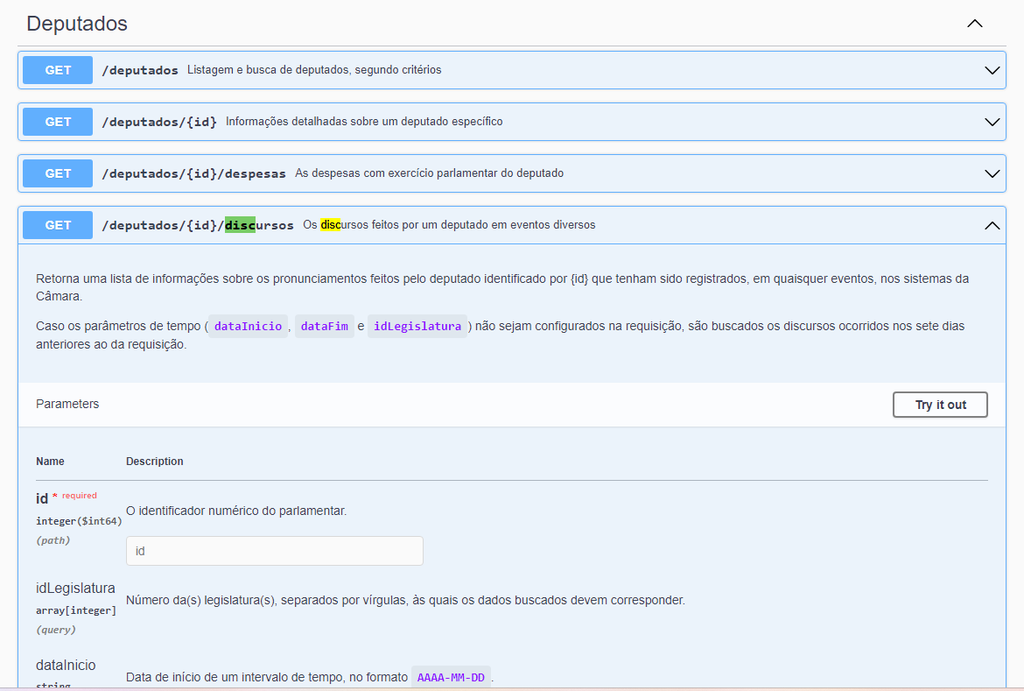

Podemos executar a requisiçãopelo site da camara, ou podemos copiar o CURL ou o Request Url e mimetizarmos a requisição para o R. Para coletar os dados 2 informações são necessárias. o Id do deputado e o código da legislatura. Ambas as informações estão disponíveis aqui na api da camara.

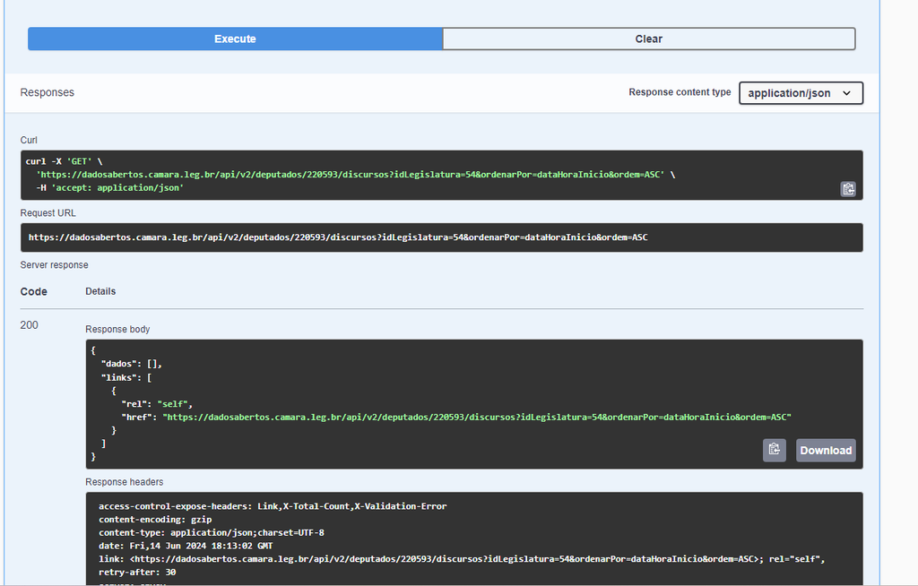

#### Executando o processo pelo R

##### Passo 1. baixando as informações dos deputados

```r
deputados <- readr::read_csv2("https://dadosabertos.camara.leg.br/arquivos/deputados/csv/deputados.csv")

dplyr::glimpse(deputados)
```

```
Rows: 7,841
Columns: 13
$ uri                  <chr> "https://dadosabertos.camara.leg.br/api/v2/deputa…
$ nome                 <chr> "Abilio Brunini", "Acácio Favacho", "Adail Filho"…
$ idLegislaturaInicial <dbl> 57, 56, 57, 57, 56, 56, 56, 48, 54, 52, 54, 54, 5…
$ idLegislaturaFinal   <dbl> 57, 57, 57, 57, 57, 57, 57, 57, 57, 57, 57, 57, 5…
$ nomeCivil            <chr> "ABILIO JACQUES BRUNINI MOUMER", "ACÁCIO DA SILVA…
$ cpf                  <lgl> NA, NA, NA, NA, NA, NA, NA, NA, NA, NA, NA, NA, N…
$ siglaSexo            <chr> "M", "M", "M", "M", "M", "F", "M", "M", "M", "M",…
$ urlRedeSocial        <chr> NA, "https://twitter.com/acaciofavacho, https://w…
$ urlWebsite           <chr> NA, NA, NA, NA, NA, NA, NA, NA, NA, NA, NA, NA, N…
$ dataNascimento       <date> 1984-01-31, 1983-09-28, 1992-02-16, 1964-06-14, …
$ dataFalecimento      <date> NA, NA, NA, NA, NA, NA, NA, NA, NA, NA, NA, NA, …
$ ufNascimento         <chr> "MT", "AP", "AM", "MG", "BA", "SP", "GO", "MG", "…
$ municipioNascimento  <chr> "Cuiabá", "Macapá", "Manaus", "Minas Novas", "Sal…
```

Agora temos acesso aos endpoints com o o ID de cada um dos deputados

```r
deputados$uri[[1]]
```

```
[1] "https://dadosabertos.camara.leg.br/api/v2/deputados/220593"
```

Nosso objetivo agora é construir o link que indique o endpoint.

```r
legislatura = 57
stringr::str_glue(deputados$uri[[1]], "/discursos?idLegislatura={legislatura}")
```

```
https://dadosabertos.camara.leg.br/api/v2/deputados/220593/discursos?idLegislatura=57
```

```r
dados_api <- stringr::str_glue(deputados$uri[[1]], "/discursos?idLegislatura={legislatura}") %>%
  jsonlite::fromJSON()
```

Apos capturar os dados podemos executar o tratamento

```r
dados_api %>%
  tibble(data = .) %>%
  slice(1) %>%
  unnest_wider(data)%>%
  unnest_longer(everything())
```

[output not shown]

### 4. Acessando API’s Escondidas

Muitos sites geram o conteúdo html através de um arquivo json. Se encontrarmos o arquivo json podemos trabalhar com dele diretamente, ou seja ao invés de acessarmos os dados entrando na url, clicando em cada um dos botões, e gerando a tabela de visualização, podemos ir direto aos dados.

Para executar esse exemplo vamos acessar o site divulga candidaturas e contas eleitorais, do tse

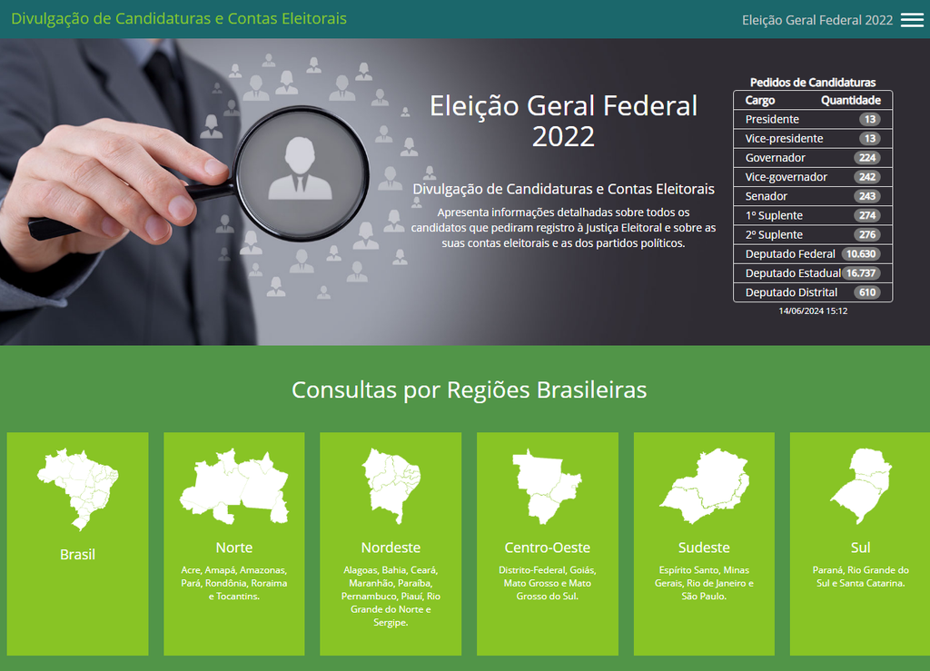

[figure not shown]

O primeiro passo é ver se encontramos a requisição ao JSON mapeando as requisições do navegador ao servidor. Como fazemos isso? Simples acessando a aba de desenvolvimento do navegador via CTRL+SHIFT+C.

[figure not shown]

Vamos até a aba de network, aqui podemos ver todas as requisições feitas entre navegador e servidor. Aqui iremos procurar arquivos xhr. Nesse caso o objeto já está nomeado como candidatos.

[figure not shown]

Uma outra forma de encontrar o .json é buscar um parametro listado na aba de pesquisa do network. Por exemplo vamos procurar o candidato Abdul

[figure not shown]

Aqui foi nos indicado qual objeto contém a informação com o nome do candidato, o procedimento agora é copiar e mimetizar a requisição. Fazemos isso clicando com o botão direito e copiando a requisição como CURL

[figure not shown]

```r
"curl 'https://divulgacandcontas.tse.jus.br/divulga/rest/v1/candidatura/listar/2022/SP/2040602022/7/candidatos' \
-H 'Accept: application/json, text/plain, */*' \
-H 'Accept-Language: pt-BR,pt;q=0.9,en-US;q=0.8,en;q=0.7' \
-H 'Connection: keep-alive' \
-H 'Cookie: _d8a23=f27b6b6091045596; TS01efa917=0103a0ceae8cba8f52a3da14dae015ad4795e26653bc487fba64d4d8141b5ccef10a2dd7febd69b018c1e1a4fedee2285ad7ede73c2e5ba10842afb9a4455d3516bf04d85f' \
-H 'Referer: https://divulgacandcontas.tse.jus.br/' \
-H 'Sec-Fetch-Dest: empty' \
-H 'Sec-Fetch-Mode: cors' \
-H 'Sec-Fetch-Site: same-origin' \
-H 'User-Agent: Mozilla/5.0 (Windows NT 10.0; Win64; x64) AppleWebKit/537.36 (KHTML, like Gecko) Chrome/123.0.0.0 Safari/537.36 OPR/109.0.0.0' \
-H 'sec-ch-ua: \"Opera GX\";v=\"109\", \"Not:A-Brand\";v=\"8\", \"Chromium\";v=\"123\"' \
-H 'sec-ch-ua-mobile: ?0' \
-H 'sec-ch-ua-platform: \"Windows\"'" %>%
  httr2::curl_translate()
```

Copiamos a url e podemos fazer a requisição via jsonlite::read_json()

```r
url <- "https://divulgacandcontas.tse.jus.br/divulga/rest/v1/candidatura/listar/2022/SP/2040602022/7/candidatos"

dados_brutos <- jsonlite::read_json(url)
```

Em seguida só precisamos estruturar os dados

```r
dados_brutos$candidatos %>%
  dplyr::tibble(data =.) %>%
  tidyr::unnest_wider(data) %>%
  janitor::clean_names()
```

[output not shown]

### Exercícios

Como exercício vamos acessar o site da [tabela fipe](https://veiculos.fipe.org.br) e vamos coletar alguns dados sobre preço de carros.

[figure not shown]

Acesse a consulta de Carros de Utilitários, identifique a API e extraia o preço de todos os carros de uma das marcas, para os três primeiros meses de referência de 2024

1. BMW
2. Audi
3. Volvo

[figure not shown]

Retorne os dados estruturados em um formato tibble como esse:

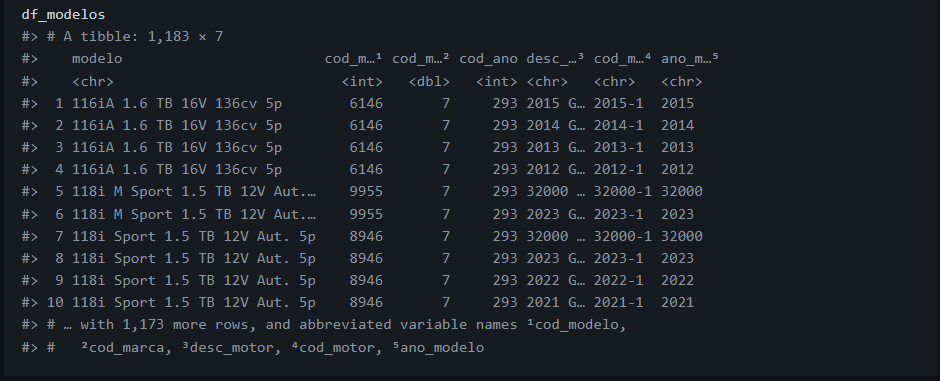